###### Virtualisation et Cloud - © TEK-UP University

# LAB05 : Docker

### Objectif

- L’objectif de ce TP est de créer une application Docker Web basique qui affiche un message d'accueil.

###### Prérequis

- Système Linux Ubuntu avec Docker installé.

###### Démarche

- Etape 1 : Création d'une application Web sur la machine locale
- Etape 2 : Création de l'application Docker
- Etape 3 : Démarrage application et gestion conteneur

## Création d'une application Web sur la machine locale

- Pour pouvoir créer notre application Web sur notre machine locale, on va procèder comme suit :
  - Installer le serveur HTTPD (Apache2)
  - Créer un fichier html contenant le message d'accueil "Hello From Docker LAB ! "
  - Faire l'accès à l'application

### Installation de HTTPD - serveur web Apache2

Apache est le serveur Web le plus couramment utilisé sur les systèmes Linux.

1- Installez Apache :

```python
$ sudo apt update
$ sudo apt install -y apache2
```

2- Vérifiez que le service est bien installé

```python
$ sudo systemctl status apache2
```

[figure not shown]

3- Ouvrez votre navigateur sur l'adresse de la machine locale (localhost) et sur le port 80 (port Apache): http://localhost:80

- vérifiez la page d'accueil Apache

[figure not shown]

4- Faites l'accès au fichier "index.html" à l'emplacement "/var/www/html" et observez son contenu

- Conclure?

**Remarque**

- Pour arreter/ démarrer le service apache2, on utilise la commande **apachectl** au lieu de **apache2** :

5- Arretez puis démarrez de nouveau le service apache2

```python
$ sudo apachectl stop
```

```python
$ sudo apachectl start
```

- Vérifiez l'état du service

```python
$ sudo systemctl status apache2
```

### Création de l'application

1- Editez le fichier "index.html" situé à l'emplacement : "/var/www/html"

```python
$ sudo nano /var/www/html/index.html
```

2- Contenu "index.html"

```python
 <!DOCTYPE html>
<html>
 <body><h1>
         Hello From Docker LAB !
    </h1></body>
</html>
```

### Accès à l'application

1- Pour faire l'accès à votre application, ouvrez votre navigateur sur l'adresse : http://localhost

[figure not shown]

## Création de l'application Web Docker

### Suppression de l'application locale

1- Avant de tarvailler avec les conteneur Docker, désinstallez apache2

```python
$ sudo apt-get purge apache2 apache2-utils apache2-bin apache2.2-common
$ sudo apt-get autoremove --purge
```

- vérifiez que Apache2 est désinstallé

```python
$ sudo systemctl status apache2
```

```python
## Résultat
Unit apache2.service could not be found.
```

### Création du fichier image Dockerfile

1- Sous votre répertoire maison, créez un répertoire de travail "webserver_project".

```python
$ mkdir webserver_project
$ cd webserver_project
```

2- Créez et éditez le fichier application "index.html"

```python
$ nano index.html
```

- Contenu de "index.html"

```python
 <!DOCTYPE html>
<html>
 <body><h1>
       Hello From Docker LAB !
    </h1></body>
</html>
```

3- Créez le fichier Dockerfile

```python
$ nano Dockerfile
```

- Contenu du Dockerfile

```python
FROM ubuntu:latest
# Update the list of packages
RUN apt -y update
# Install Apache
RUN apt install -y apache2
# Define the working directory
WORKDIR /var/www/html
COPY index.html .
# Application Port
CMD ["apachectl", "start"]
```

**Explication**

**- FROM ubuntu:latest** : Définit l'image de base, on va utiliser la dernière version de ubuntu:latest disponible sur Docker Hub

**- RUN apt update** : Met à jour de la liste des paquetages

**- RUN apt-get install apache2 -y** : Installe apache2

**- WORKDIR /var/www/html** : Crée/définit un répertoire de travail sur le système de fichiers de l'image  
**- COPY index.html .** : Copie le fichier "index.html" qui se trouve dans le répertoire de travail vers le système de fichiers de l'image (/var/www/html).

**- CMD ["apachectl", "start"]** : précise à Docker Deamon la commande à exécuter pour lancer l'application.

### Création de l'image "webserver"

1- Créez l'image de l'application **"webserver:version0"** avec la commande "docker build"

- Le point (.) en fin indique le chemin de l'image (le dossier courant)

```python
$ docker build -t webserver:version0 .
```

- Le processus de création de l'image s'arrête au niveau de la tâche "apt install -y apache2" pour demander la sélection des paramètres région et zone horaire (configuration tzdata)

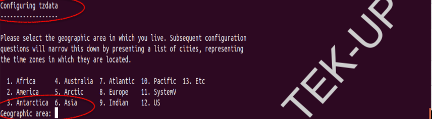

###### Modification 1

2- Pour éviter le mode intéractif lors de l'installation de Apache, quittez le processus de création image et éditez de nouveau votre Dockerfile.

```
- Pour désactiver le mode intéractif en ajoutant la ligne "ARG DEBIAN_FRONTEND=noninteractive"
```

```python
FROM ubuntu:latest
# Update the list of packages
RUN apt -y update
#The following ARG turns off the questions normally asked for location and timezone for Apache
ARG DEBIAN_FRONTEND=noninteractive
# Install Apache
RUN apt -y install apache2
WORKDIR /var/www/html
COPY index.html .
# Application Port
EXPOSE 80
CMD ["apachectl", "start"]
```

3- Après mofification, créez une nouvelle image webserver qui porte la version1 : **"webserver:version1"**

```python
$ docker build -t webserver:version1 .
```

- Après désactivation du mode intéractif, Docker installe apache2 en sélectionnant les paramètres région par défaut.

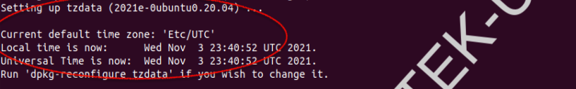

2- Vérifiez que l'image existe dans le dépôt local

```python
$ docker images
```

```python
#Résultat
REPOSITORY   TAG       IMAGE ID       CREATED              SIZE
webserver    version1    61502f1bd13a   About a minute ago   217MB
ubuntu       latest    ba6acccedd29   2 weeks ago          72.8MB
```

### Création et démarage du conteneur image webserver

1- Démarrez un nouveau conteneur, nommée "webcontainer1", basé sur l'image "webserver:version1"

```python
$ docker run --name webcontainer1 webserver:version1
```

2- Après démarrage du conteneur, vérifiez s'il est actif ou non

```python
$ docker ps
```

```python
## Résultat
CONTAINER ID   IMAGE     COMMAND   CREATED   STATUS    PORTS     NAMES
```

- Note : Pour que le conteneur reste actif, il faut exécuter le service principal en premier plan (FOREGROUND)

###### Modification 2

3- Editez le fichier Dockerfile de nouveau.

```
- Remplacez la  commande "apachectl start" par
"apachectl -D FOREGROUND"
```

```python
FROM ubuntu:latest
# Update the list of packages
RUN apt -y update
#The following ARG turns off the questions normally asked for location and timezone for Apache
ARG DEBIAN_FRONTEND=noninteractive
# Install Apache
RUN apt -y install apache2
WORKDIR /var/www/html
COPY index.html .
# Application Port
EXPOSE 80
CMD ["apachectl", "-D", "FOREGROUND"]
```

4- Créez de nouveau l'image **webserver:version2**

```python
$ docker build -t webserver:version2 .
```

5- Démarrez un nouveau conteneur webcontainer2 à partir de l'image **webserver:version2**

```python
$ docker run --name webcontainer2 webserver:version2
```

- Une fois démarré, le conteneur s'exécute en premier plan sur le terminal.
- Le conteneur affiche le message suivant : "AH00558: apache2: Could not reliably determine the server's fully qualified domain name, using 172.17.0.4. Set the 'ServerName' directive globally to suppress this message "

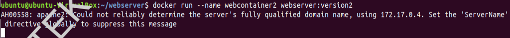

- Pour éviter ce message, on doit ajouter la ligne "servername hostname" au fichier de configuration Apache à l'emplacement "/etc/apache2/apache2.conf"

###### Modification 3

6- Modifiez le fichier Dockerfile, une dernière fois, pour apporter cette modification

```
- on va ajouter la ligne :
RUN   echo "servername hostname" >> /etc/apache2/apache2.conf
```

```python
FROM ubuntu:latest
# Update the list of packages
RUN apt -y update
#The following ARG turns off the questions normally asked for location and timezone for Apache
ARG DEBIAN_FRONTEND=noninteractive
# Install Apache
RUN apt -y install apache2
# Configuration
RUN   echo "servername hostname" >> /etc/apache2/apache2.conf

# Define the working directory
WORKDIR /var/www/html
COPY index.html .
# Application Port
EXPOSE 80
CMD ["apachectl", "-D", "FOREGROUND"]
```

7- Créez la nouvelle image "webserver:version3"

```python
$ docker build -t webserver:version3 .
```

8- Démarrez un nouveau conteneur webcontainer3 à partir de l'image webserver

```python
$ docker run --name webcontainer3 webserver:version3
```

- Une fois démarré, le conteneur s'exécute en premier plan sur le terminal.
- Pour vérifier le fonctionnement de l'application web et consulter sa page d'accueil, on doit consulter le navigateur web sur l'adresse du conteneur et le port de l'application.

### Accès application

1- Pour déterminer l'adresse IP du conteneur, ouvrez un nouvel terminal et exécutez la commande suivante pour repérer l'adresse IP du conteneur :

```python
$ docker inspect  webcontainer3 | grep IP
```

```python
# Résultat
 docker inspect webcontainer3 | grep IP
            "LinkLocalIPv6Address": "",
            "LinkLocalIPv6PrefixLen": 0,
            "SecondaryIPAddresses": null,
            "SecondaryIPv6Addresses": null,
            "GlobalIPv6Address": "",
            "GlobalIPv6PrefixLen": 0,
            "IPAddress": "172.17.0.3",
            "IPPrefixLen": 16,
            "IPv6Gateway": "",
                    "IPAMConfig": null,
                    "IPAddress": "172.17.0.3",
                    "IPPrefixLen": 16,
                    "IPv6Gateway": "",
                    "GlobalIPv6Address": "",
                    "GlobalIPv6PrefixLen": 0,
```

- D'après le résultat de la commande ici, l'adresse du conteneur est 172.17.0.3

3- Consultez votre navigateur à l'adresse spécifiée

[figure not shown]

4- Arretez le conteneur webcontainer3.

```python
$ docker stop webcontainer3
```

### Accès à l'application Docker depuis la machine hôte

#### Méthode 1 : port mapping

- Pour faire l'accès à l'application conteneurisée sur la machine hôte, on va faire le mapping entre port conteneur et port machine hôte.

```python
$ docker run -d -p 3000:80 --name webcontainer4 webserver:version3
```

```
- L'option " -p 3000:80" permet de relayer le flux du port conteneur 80 au port hôte 3000.
- L'option "-d" permet d'exécuter le conteneur en arrière plan.
```

2- Pour faire l'accès à l'application, consultez l'adresse "http://localhost:3000" sur votre navigateur.

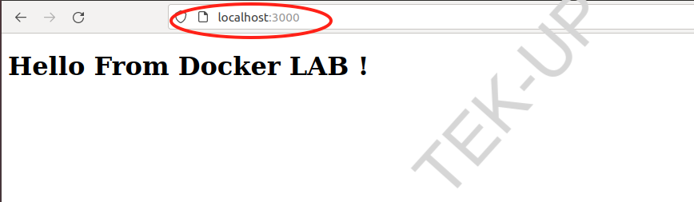

#### Méthode 2 : option "network"

- Pour faire l'accès à l'application conteneurisée sur la machine hôte, on va démarrer, en arrière plan, un conteneur nommé "webcontainer5" avec l'option"--network=host"

  ```
  - L'option " network=host" permet de placer le conteneur  sur le même réseau que la machine hôte.
  ```

1- Démarrez, en arrière plan, un conteneur nommé "webcontainer5" avec l'option" --network=host"

```python
$ docker run -d --network=host --name webcontainer5 websever:version3
```

2- Pour faire l'accès à l'application, consultez l'adresse "http://localhost:80" sur votre navigateur.

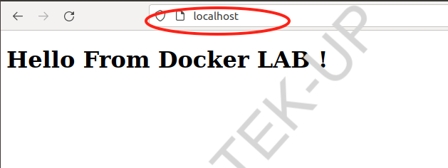

###### Virtualisation et Cloud - © TEK-UP University